# Project 7: Conclusions

# Task 1

1. What is the optimal number of store formats? How did you arrive at that number? The optimal number of store formats is 3. I determined this by first summarizing sales data for each store in 2015. Then, I determined the optimal number of clusters assuming a kmeans cluster method through the Calinski-Harabasz, and numerous other, cluster validation methods.
2. How many stores fall into each store format? Per the table below, cluster 1 contains 17 stores, cluster 2 contains 35 stores, and cluster 3 contains 33 stores.

| cluster | count |
| --- | --- |
| 1 | 17 |
| 2 | 35 |
| 3 | 33 |

|  | store | year | dry_grocery | dairy | frozen_food | meat | produce | floral | deli | bakery | general_merchandise | total | cluster | total_sales |
| --- | --- | --- | --- | --- | --- | --- | --- | --- | --- | --- | --- | --- | --- | --- |
| 1 | S0001 | 2015 | 46.13473 | 10.308371 | 7.719925 | 10.767741 | 9.717104 | 0.6769433 | 4.354993 | 3.554388 | 6.765810 | 100 | 2 | 23508946 |
| 2 | S0002 | 2015 | 45.75279 | 10.638761 | 7.884093 | 11.490345 | 10.125940 | 0.7438059 | 3.979242 | 2.970153 | 6.414865 | 100 | 2 | 17334620 |
| 3 | S0003 | 2015 | 42.13491 | 10.235628 | 6.902750 | 11.471274 | 12.539881 | 0.9631393 | 4.176080 | 3.610802 | 7.965537 | 100 | 3 | 30240662 |
| 4 | S0004 | 2015 | 45.45598 | 9.711102 | 8.027714 | 12.772766 | 10.040922 | 0.6119628 | 4.178524 | 3.446871 | 5.754154 | 100 | 2 | 27913891 |
| 5 | S0005 | 2015 | 44.01688 | 10.626809 | 8.633852 | 10.186326 | 13.111205 | 0.8877250 | 3.538921 | 2.260686 | 6.737600 | 100 | 3 | 27825886 |
| 6 | S0006 | 2015 | 45.98352 | 9.860922 | 7.444313 | 10.691591 | 10.178203 | 0.8265039 | 4.630887 | 3.541689 | 6.842375 | 100 | 2 | 34625421 |
| 7 | S0007 | 2015 | 44.20868 | 10.213496 | 8.916985 | 11.513459 | 10.344684 | 0.7838334 | 4.629766 | 3.017637 | 6.371459 | 100 | 2 | 30863087 |
| 8 | S0008 | 2015 | 42.84569 | 10.873213 | 8.032146 | 10.687773 | 12.369636 | 0.7858796 | 3.262266 | 2.239774 | 8.903627 | 100 | 3 | 29181880 |
| 9 | S0009 | 2015 | 44.22523 | 10.037612 | 7.705136 | 11.890801 | 10.350749 | 0.7288256 | 4.420394 | 2.575634 | 8.065621 | 100 | 2 | 40678620 |
| 10 | S0010 | 2015 | 43.14454 | 11.496155 | 8.034174 | 10.714830 | 12.162884 | 1.0383022 | 3.709895 | 3.805137 | 5.894088 | 100 | 3 | 21703928 |

[output cut: 75 more lines]

| cluster | dry_grocery | dairy | frozen_food | meat | produce | floral | deli | bakery | general_merchandise |
| --- | --- | --- | --- | --- | --- | --- | --- | --- | --- |
| 1 | 45.76879 | 9.942591 | 8.043377 | 10.34993 | 10.14924 | 0.7395450 | 3.768407 | 2.181581 | 9.056539 |
| 2 | 45.36276 | 9.999336 | 7.654673 | 11.97880 | 10.13560 | 0.6890878 | 4.412960 | 2.866726 | 6.900059 |
| 3 | 43.72736 | 10.637234 | 8.069311 | 10.63550 | 12.25867 | 0.9894330 | 3.800043 | 3.044142 | 6.838313 |

4. Please provide a map created in Tableau that shows the location of the existing stores, uses color to show cluster, and size to show total sales. Make sure to include a legend! Feel free to simply copy and paste the map into the submission template. The below Tableau map displays the store locations, colored by cluster. https://public.tableau.com/profile/michael.gysel#!/vizhome/StoreClusters_10/Dashboard1?publish=yes

# Task 2

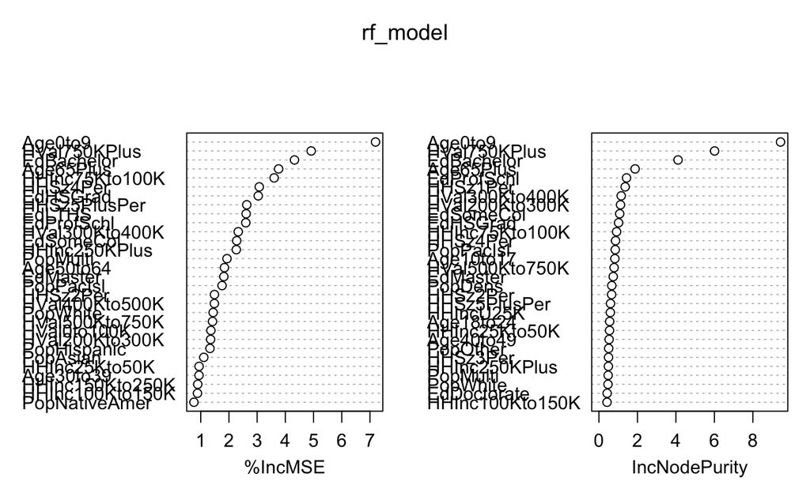

|  | X | Type |
| --- | --- | --- |
| 85 | 85 | Existing |
| 86 | 86 | New |
| 87 | 87 | New |
| 88 | 88 | New |
| 89 | 89 | New |
| 90 | 90 | New |
| 91 | 91 | New |
| 92 | 92 | New |
| 93 | 93 | New |
| 94 | 94 | New |

[output cut: 1 more lines]

# Task 3

1. What type of ETS or ARIMA model did you use for each forecast? Use ETS(a,m,n) or ARIMA(ar, i, ma) notation. How did you come to that decision? An ETS(M,N,M) Model was used. After assessing the time series decomposition plot, it became clear the Error is Multiplicative, Trend is None, and Seasonality is Multiplicative. This ETS Model yielded a higher accuracy than the ARIMA Model, so it was chosen for the time series forecast.
2. Please provide a table of your forecasts for existing and new stores. Also, provide visualization of your forecasts that includes historical data, existing stores forecasts, and new stores forecasts. The table below shows the produce sales forecasts for existing and new stores for 2016. The link below shows the data visualization of total produce sales. https://public.tableau.com/profile/michael.gysel#!/vizhome/P7-TotalProduceSales/Dashboard1?publish=yes

|  | Existing.Stores | New.Stores |
| --- | --- | --- |
| Jan-16 | 20705352 | 2435924 |
| Feb-16 | 20110037 | 2365887 |
| Mar-16 | 23667529 | 2784415 |
| Apr-16 | 22453553 | 2641594 |
| May-16 | 25493363 | 2999219 |
| Jun-16 | 25858644 | 3042193 |
| Jul-16 | 26340299 | 3098859 |
| Aug-16 | 23118849 | 2719865 |
| Sep-16 | 20624065 | 2426361 |
| Oct-16 | 20267316 | 2384390 |

[output cut: 2 more lines]